# Diamond analysis

A.Izquierdo

27/5/2020

# Introduction

This is a presentation showing a quick data analysis App published in ShyniApps.io in this [link](https://agizes.shinyapps.io/w4-assignment/). The github repo with the source files is in this [link](https://github.com/agizes/DDP-datascience/tree/master/project) We’ve used the *diamonds* dataset as source of information. In this presentation we’ll go through the application and explain its usage.

The *user interface* file contains four tabs.

- **Basic data.** Shows a summary of the Diamonds dataset and the first three rows of values. The information can be filtered by diamond cut clicking the checkbox and selecting the cut type in the dropdown list. In case the checkbox is not selected, no filter is applied.
- **Simple plot and model.** Displays a carat vs. price plot and a linear model fitting prices based on the number of carats. With a slider, the user can move along the model selecting the number of carats and get an estimation of the price (based on the model prediction.
- **Filtered plot and model.** In this tab the user can select the diamond color and both the plot and a liner model (carats vs. price) will be filtered with the selection. Like in tab 2, the user can move along the linear fit selecting the number of carats with a slider to see the estimated diamond price.
- **How-to.** Finally the last tab shows the basic documnentation you’re reading on how to use the aplication

# Basic Data exploration

In the first tab, the user can get a summary of the diamonds data. Data can be filtered by cut type.

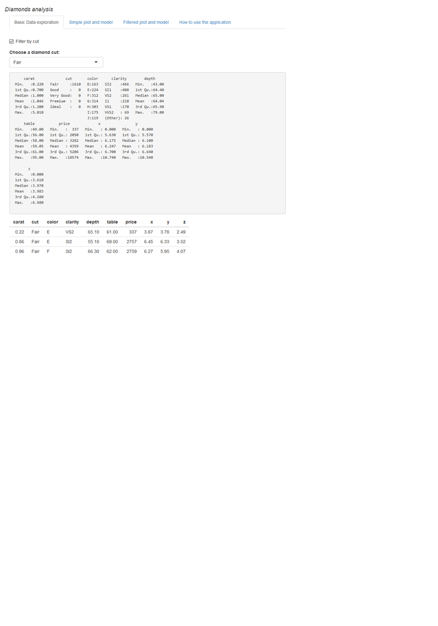

# Simple plot and model

In the second tab, the user gets a plot of price vs. carats and a linear model that fits both variables. Selecting the carat mass, the user can get the predicted diamond value.

[figure not shown]

# Filtered plot and model

In the third tab, the user gets a plot of price vs. carats and a linear model that fits both variables after filtering the diamond color. Like in the previous tab, the user can select the carat mass, the user can get the predicted diamond value. This second analysis provides an interesting insight compared to the previous one.

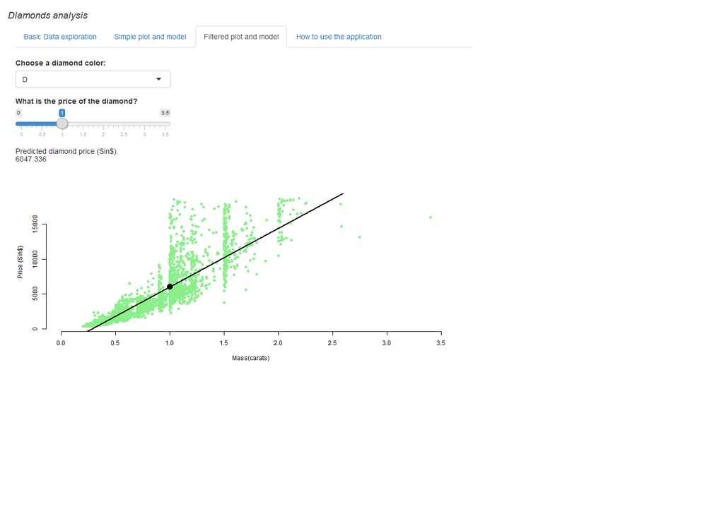